# Bellabeat Capstone Project

Kaloyan Kirilov

2023-04-02

# Bellabeat Capstone Project in R

## Introduction to the Project

The following represents an overview of the key parts of a case study with which I was tasked at the final stage of the Google Data Analytics Professional Certificate. This project analyses data of more than 30 FitBit users in the span of a month in order to gain insights that would inform the growth and marketing strategies of Bellabeat.

### About the company

Bellabeat is a high-tech manufacturer of health-focused products for women, such as a wellness tracker, a wellness watch, a water bottle that tracks daily water intake, and an app that provides users with health data.

As the company is looking for more opportunities for growth, they have tasked me with analyzing smart device usage data in order to identify consumer trends and propose high-level recommendations to inform the Bellabeat’s marketing strategy.

### Business task

Identify new growth opportunities in order to scale the business and become a larger player in the global smart device market.

I will do this by identifying consumer trends in wellness smart device usage and propose recommendations with the aim to exploit those trends.

### About the data

After having determined the questions we will answer through this data, it is time to proceed to the data preparation stage.

## Data preparation

The data has been downloaded and stored into a local hard disk. No additional security measures seem necessary as the data is openly available for download. The data itself is anonymized, which adds a layer of protection for the subjects whose data I will be working with.

The data is not current, as it was gathered in 2016, while the analysis is performed in 2023. In addition, its reliability is questionable as it reflects consumer usage of FitBit devices, yet it is collected via an Amazon Mechanical Turk survey and uploaded on Kaggle. In this context, it is impossible to properly verify the data’s integrity.

Further limitations linked to the dataset are reified by the small sample size - 33 subjects have shared their data for the majority of the aspects being tracked, such as a general daily overview of the subjects’ activities, as well as hourly data for their intensitieis, steps, and calories.

Meanwhile, there were only 14 subjects that have shared their heart rate data, 24 subjects sharing their sleep data, and 8 subjects having shared weight data. All the data is also limited in time, as it tracks only a one month time period (April - May 2016).

These limitations pose serious concerns over the integrity and reliability of the data and the conclusions that can be gathered thereof, yet do not take away from the main purpose of this exercise - namely, to apply and showcase some of the skills learned during the Google Data Analytics Professional Certificate.

Next, I will move on to the data processing stage of the process.

## Data processing

### Loading packages

```r
library(tidyverse)
library(ggpubr)
library(lubridate)
library(here)
library(skimr)
library(janitor)
library(chron)
library(plyr)
library(anytime)
library(data.table)
library(hms)
library(gridExtra)
```

### Importing the relevant data sets

While there are 18 data sets in the database, including a daily activity data set, daily, hourly, and minutely data sets for calories, intensities, and steps, as well as daily sleep data set, weight data set, and secondly heartrate data set.

I will exclude some data sets due to the small sample size, such as the weigh data set, and data sets that comprise of data already included in a more general data set, such as with the daily data for calories included in activity.

```r
heartrate_seconds <- read.csv("E:/Work/Data Analysis/Google Data Analytics Certificate/Course 8 - Capstone project/Bellabeat Project/Fitbit Dataset/heartrate_seconds_merged.csv")
activity <- read.csv("E:/Work/Data Analysis/Google Data Analytics Certificate/Course 8 - Capstone project/Bellabeat Project/Fitbit Dataset/dailyActivity_merged.csv")
calories <- read.csv("E:/Work/Data Analysis/Google Data Analytics Certificate/Course 8 - Capstone project/Bellabeat Project/Fitbit Dataset/hourlyCalories_merged.csv")
intensities <- read.csv("E:/Work/Data Analysis/Google Data Analytics Certificate/Course 8 - Capstone project/Bellabeat Project/Fitbit Dataset/hourlyIntensities_merged.csv")
steps <- read.csv("E:/Work/Data Analysis/Google Data Analytics Certificate/Course 8 - Capstone project/Bellabeat Project/Fitbit Dataset/hourlySteps_merged.csv")
sleep <- read.csv("E:/Work/Data Analysis/Google Data Analytics Certificate/Course 8 - Capstone project/Bellabeat Project/Fitbit Dataset/sleepDay_merged.csv")
```

### Cleaning the data

#### Checking for duplicates

```r
sum(duplicated(heartrate_seconds))
```

```
## [1] 0
```

```r
sum(duplicated(activity))
```

```
## [1] 0
```

```r
sum(duplicated(calories))
```

```
## [1] 0
```

```r
sum(duplicated(intensities))
```

```
## [1] 0
```

```r
sum(duplicated(steps))
```

```
## [1] 0
```

```r
sum(duplicated(sleep))
```

```
## [1] 3
```

#### Removing duplicates

```r
sleep <- distinct(sleep)
sum(duplicated(sleep))
```

```
## [1] 0
```

#### Exploring the data

```r
glimpse(heartrate_seconds)
```

```
## Rows: 2,483,658
## Columns: 3
## $ Id    <dbl> 2022484408, 2022484408, 2022484408, 2022484408, 2022484408, 2022…
## $ Time  <chr> "4/12/2016 7:21:00 AM", "4/12/2016 7:21:05 AM", "4/12/2016 7:21:…
## $ Value <int> 97, 102, 105, 103, 101, 95, 91, 93, 94, 93, 92, 89, 83, 61, 60, …
```

```r
glimpse(activity)
```

```
## Rows: 940
## Columns: 15
## $ Id                       <dbl> 1503960366, 1503960366, 1503960366, 150396036…
## $ ActivityDate             <chr> "4/12/2016", "4/13/2016", "4/14/2016", "4/15/…
## $ TotalSteps               <int> 13162, 10735, 10460, 9762, 12669, 9705, 13019…
## $ TotalDistance            <dbl> 8.50, 6.97, 6.74, 6.28, 8.16, 6.48, 8.59, 9.8…
## $ TrackerDistance          <dbl> 8.50, 6.97, 6.74, 6.28, 8.16, 6.48, 8.59, 9.8…
## $ LoggedActivitiesDistance <dbl> 0, 0, 0, 0, 0, 0, 0, 0, 0, 0, 0, 0, 0, 0, 0, …
## $ VeryActiveDistance       <dbl> 1.88, 1.57, 2.44, 2.14, 2.71, 3.19, 3.25, 3.5…
## $ ModeratelyActiveDistance <dbl> 0.55, 0.69, 0.40, 1.26, 0.41, 0.78, 0.64, 1.3…
## $ LightActiveDistance      <dbl> 6.06, 4.71, 3.91, 2.83, 5.04, 2.51, 4.71, 5.0…
## $ SedentaryActiveDistance  <dbl> 0, 0, 0, 0, 0, 0, 0, 0, 0, 0, 0, 0, 0, 0, 0, …
## $ VeryActiveMinutes        <int> 25, 21, 30, 29, 36, 38, 42, 50, 28, 19, 66, 4…
## $ FairlyActiveMinutes      <int> 13, 19, 11, 34, 10, 20, 16, 31, 12, 8, 27, 21…
## $ LightlyActiveMinutes     <int> 328, 217, 181, 209, 221, 164, 233, 264, 205, …
## $ SedentaryMinutes         <int> 728, 776, 1218, 726, 773, 539, 1149, 775, 818…
## $ Calories                 <int> 1985, 1797, 1776, 1745, 1863, 1728, 1921, 203…
```

```r
glimpse(calories)
```

```
## Rows: 22,099
## Columns: 3
## $ Id           <dbl> 1503960366, 1503960366, 1503960366, 1503960366, 150396036…
## $ ActivityHour <chr> "4/12/2016 12:00:00 AM", "4/12/2016 1:00:00 AM", "4/12/20…
## $ Calories     <int> 81, 61, 59, 47, 48, 48, 48, 47, 68, 141, 99, 76, 73, 66, …
```

```r
glimpse(intensities)
```

```
## Rows: 22,099
## Columns: 4
## $ Id               <dbl> 1503960366, 1503960366, 1503960366, 1503960366, 15039…
## $ ActivityHour     <chr> "4/12/2016 12:00:00 AM", "4/12/2016 1:00:00 AM", "4/1…
## $ TotalIntensity   <int> 20, 8, 7, 0, 0, 0, 0, 0, 13, 30, 29, 12, 11, 6, 36, 5…
## $ AverageIntensity <dbl> 0.333333, 0.133333, 0.116667, 0.000000, 0.000000, 0.0…
```

```r
glimpse(sleep)
```

```
## Rows: 410
## Columns: 5
## $ Id                 <dbl> 1503960366, 1503960366, 1503960366, 1503960366, 150…
## $ SleepDay           <chr> "4/12/2016 12:00:00 AM", "4/13/2016 12:00:00 AM", "…
## $ TotalSleepRecords  <int> 1, 2, 1, 2, 1, 1, 1, 1, 1, 1, 1, 1, 1, 1, 1, 1, 1, …
## $ TotalMinutesAsleep <int> 327, 384, 412, 340, 700, 304, 360, 325, 361, 430, 2…
## $ TotalTimeInBed     <int> 346, 407, 442, 367, 712, 320, 377, 364, 384, 449, 3…
```

While also using the str() and head() functions, I observed that the ‘date’ and ‘time’ columns in each table are in the ‘chr’ data type, which will cause issues with the analysis down the road. In addition, some data sets have the ‘time’ varibale, while others do not. Further, the name of the variables is not consistent along all the data sets. Thus, the data requries further cleaning and transformation before being ready to be merged.

#### Cleaning the date and time irregularities

#### Excluding irrelevant columns from some data sets

```r
# For 'activity'
activity$ActivityDate=as.POSIXct(activity$ActivityDate, format="%m/%d/%Y", tz="UTC")
colnames(activity)[colnames(activity) == "ActivityDate"] = "Date"

# For 'calories'
calories$ActivityHour=as.POSIXct(calories$ActivityHour, format="%m/%d/%Y %I:%M:%S %p", tz="UTC")
calories$Date <- as.Date(calories$ActivityHour, format = "%m/%d/%y", tz="UTC")
calories$Time <- times(strftime(calories$ActivityHour, "%H:%M:%S", tz="UTC"))
calories <- calories[, c(1,4,5,3)]

# For 'intensities'
intensities$ActivityHour=as.POSIXct(intensities$ActivityHour, format="%m/%d/%Y %I:%M:%S %p", tz="UTC")
intensities$Date <- as.Date(intensities$ActivityHour, format = "%m/%d/%y", tz="UTC")
intensities$Time <- times(strftime(intensities$ActivityHour, "%H:%M:%S", tz="UTC"))
intensities <- intensities[, c(1, 5, 6, 3, 4)]

# For 'sleep'
sleep$SleepDay=as.POSIXct(sleep$SleepDay, format="%m/%d/%Y %I:%M:%S %p", tz="UTC")
colnames(sleep)[colnames(sleep) == "SleepDay"] = "Date"
sleep$Date <- as.Date(sleep$Date, format = "%Y-%m-%d", tz="UTC")

# For 'steps'
steps$ActivityHour=as.POSIXct(steps$ActivityHour, format="%m/%d/%Y %I:%M:%S %p", tz="UTC")
steps$Date <- as.Date(steps$ActivityHour, format = "%m/%d/%y", tz="UTC")
steps$Time <- times(strftime(steps$ActivityHour, "%H:%M:%S", tz="UTC"))
steps <- steps[, c(1, 4, 5, 3)]
```

The heartrate data set would require special attention as I also intend to aggregate the data in average hourly heartrate in order to merge it with the other hourly data sets.

```r
# For heartrate_seconds
heartrate_seconds$Datetime=as.POSIXct(heartrate_seconds$Time, format="%m/%d/%Y %I:%M:%S %p", tz="UTC")
heartrate_seconds <- heartrate_seconds[, c(1, 4, 3)]
heartrate_seconds$Datetime2 <- droplevels(cut(heartrate_seconds$Datetime, breaks="hour"))
heartrate_seconds$Datetime2 = as.POSIXct(heartrate_seconds$Datetime2, format="%Y-%m-%d %H:%M:%S", tz='UTC')
heartrate_hourly <- heartrate_seconds %>%
    group_by(Id, Datetime2) %>%
    aggregate(Value ~ Id + Datetime2, FUN=mean)
heartrate_hourly$Date <- as.Date(anytime(as.factor(heartrate_hourly$Datetime2), tz='UTC'), format = '%Y-%m-%d', tz='CET')
heartrate_hourly$Time <- times(strftime(heartrate_hourly$Datetime2, format = '%H:%M:%S', tz='UTC'))
heartrate_hourly <- heartrate_hourly[, c(1, 3, 5, 4)]
```

## Analyzing the data

The analysis of the data requries for it to be formatted, organized, sorted, and transformed.

I have already renamed and formated some of the data sets in the previous step.

In addition, I observed that there are records where (a) the expended daily calories are 0, (b) the total amount of minutes recorded are less than 120, or (c) the daily expended calories are less than 200, which is impossible for a living person. This could be due to, among others, detaching the tracking device from one’s body, battery shortage, or faulty device. In any case, those 9 data points are outliers and I will filter them out for the sake of a cleaner data set.

```r
activity <- filter(activity, VeryActiveMinutes+FairlyActiveMinutes+LightlyActiveMinutes+SedentaryMinutes > 120 & Calories > 200)
```

Further, I will proceed to joining several of the data sets together, which will make working with them easier. I will combine all the data sets that are based on temporal characteristcs. Thus, I will merge the general daily activity data set with the daily sleep data set. Then, I will merge hourly data sets for calories, intensities, steps, and heartrate. As there are fewer observations for the heartrate data set than for the other three, I will create two separate tables - one containing the three horly data sets except heartrate, and one extended table including heartrate.

*Note that the heartrate data set has already been transformed from secondly to hourly in the previous stage so as to allow joining it with the rest.*

### Merging data sets

```r
merged_activity_sleep <- inner_join(sleep, activity, by=c('Id', 'Date'))
merged_hourly <- join_all(list(calories, intensities, steps), by=c('Id', 'Date', 'Time'))
merged_hourly_extended <- inner_join(merged_hourly, heartrate_hourly, by=c('Id', 'Date', 'Time'))
colnames(merged_hourly_extended)[colnames(merged_hourly_extended) == "Value"] = "AverageHeartrate"
```

```r
summary(merged_activity_sleep)
```

```
##        Id                 Date                        TotalSleepRecords
##  Min.   :1.504e+09   Min.   :2016-04-12 00:00:00.00   Min.   :1.00
##  1st Qu.:3.977e+09   1st Qu.:2016-04-19 00:00:00.00   1st Qu.:1.00
##  Median :4.703e+09   Median :2016-04-26 12:00:00.00   Median :1.00
##  Mean   :5.003e+09   Mean   :2016-04-26 10:35:17.65   Mean   :1.12
##  3rd Qu.:6.962e+09   3rd Qu.:2016-05-04 00:00:00.00   3rd Qu.:1.00
##  Max.   :8.792e+09   Max.   :2016-05-12 00:00:00.00   Max.   :3.00
##  TotalMinutesAsleep TotalTimeInBed    TotalSteps    TotalDistance
##  Min.   : 58.0      Min.   : 61.0   Min.   :  254   Min.   : 0.160
##  1st Qu.:361.0      1st Qu.:405.2   1st Qu.: 5226   1st Qu.: 3.607
##  Median :433.0      Median :463.0   Median : 8920   Median : 6.285
##  Mean   :419.5      Mean   :458.8   Mean   : 8557   Mean   : 6.042
##  3rd Qu.:490.5      3rd Qu.:526.2   3rd Qu.:11389   3rd Qu.: 8.023
##  Max.   :796.0      Max.   :961.0   Max.   :22770   Max.   :17.540
##  TrackerDistance  LoggedActivitiesDistance VeryActiveDistance
##  Min.   : 0.160   Min.   :0.0000           Min.   : 0.000
##  1st Qu.: 3.607   1st Qu.:0.0000           1st Qu.: 0.000
##  Median : 6.285   Median :0.0000           Median : 0.575
##  Mean   : 6.037   Mean   :0.1094           Mean   : 1.453
##  3rd Qu.: 7.975   3rd Qu.:0.0000           3rd Qu.: 2.380
##  Max.   :17.540   Max.   :4.0817           Max.   :12.540
##  ModeratelyActiveDistance LightActiveDistance SedentaryActiveDistance
##  Min.   :0.0000           Min.   :0.160       Min.   :0.0000000
##  1st Qu.:0.0000           1st Qu.:2.547       1st Qu.:0.0000000
##  Median :0.4200           Median :3.675       Median :0.0000000
##  Mean   :0.7475           Mean   :3.810       Mean   :0.0009314
##  3rd Qu.:1.0400           3rd Qu.:4.923       3rd Qu.:0.0000000
##  Max.   :6.4800           Max.   :9.480       Max.   :0.1100000
##  VeryActiveMinutes FairlyActiveMinutes LightlyActiveMinutes SedentaryMinutes
##  Min.   :  0.00    Min.   :  0.00      Min.   : 17.0        Min.   : 125.0
##  1st Qu.:  0.00    1st Qu.:  0.00      1st Qu.:158.0        1st Qu.: 633.5
##  Median :  9.00    Median : 11.00      Median :208.5        Median : 717.5
##  Mean   : 25.17    Mean   : 18.01      Mean   :217.6        Mean   : 715.6
##  3rd Qu.: 38.00    3rd Qu.: 27.00      3rd Qu.:263.0        3rd Qu.: 783.2
##  Max.   :210.00    Max.   :143.00      Max.   :518.0        Max.   :1265.0
##     Calories
##  Min.   : 741
##  1st Qu.:1853
##  Median :2216
##  Mean   :2399
##  3rd Qu.:2924
##  Max.   :4900
```

```r
summary(merged_hourly)
```

```
##        Id                 Date                 Time             Calories
##  Min.   :1.504e+09   Min.   :2016-04-12   Min.   :00:00:00   Min.   : 42.00
##  1st Qu.:2.320e+09   1st Qu.:2016-04-19   1st Qu.:05:00:00   1st Qu.: 63.00
##  Median :4.445e+09   Median :2016-04-26   Median :11:00:00   Median : 83.00
##  Mean   :4.848e+09   Mean   :2016-04-26   Mean   :11:24:57   Mean   : 97.39
##  3rd Qu.:6.962e+09   3rd Qu.:2016-05-03   3rd Qu.:17:00:00   3rd Qu.:108.00
##  Max.   :8.878e+09   Max.   :2016-05-12   Max.   :23:00:00   Max.   :948.00
##  TotalIntensity   AverageIntensity   StepTotal
##  Min.   :  0.00   Min.   :0.0000   Min.   :    0.0
##  1st Qu.:  0.00   1st Qu.:0.0000   1st Qu.:    0.0
##  Median :  3.00   Median :0.0500   Median :   40.0
##  Mean   : 12.04   Mean   :0.2006   Mean   :  320.2
##  3rd Qu.: 16.00   3rd Qu.:0.2667   3rd Qu.:  357.0
##  Max.   :180.00   Max.   :3.0000   Max.   :10554.0
```

### Additional sorting and transformation

The data needs to be further sorted and transformed in order to be able to identify patterns, such as:

- days of week in which users take the most steps
- days of the week in which users spent the most amount of time sleeping
- days of the week in which users are most active (in terms of recorded ‘intensities’)
- days of the week in which users exhaust the most amount of calories
- hours in which users are the most active (in terms of recorded ‘intensities’)

```r
# This code links each data point with the day of the week
# assosicated with its date. Then, it gives an order to the list
# based on the order of the days of the week. Finally, it proceeds
# to group all the data points by the associated day of the week
# and aggregating the data to find the mean for the total steps
# and total time spent in bed associated which each day of the week.

weekday_steps_sleep <- merged_activity_sleep %>%
  mutate(weekday = weekdays(Date))

weekday_steps_sleep$weekday <- ordered(weekday_steps_sleep$weekday,
                                       levels=c("Monday", "Tuesday", "Wednesday",
                                                "Thursday", "Friday", "Saturday",
                                                "Sunday"))

weekday_steps_sleep <- weekday_steps_sleep %>%
  dplyr::group_by(weekday) %>%
  dplyr::summarise(mean_steps = mean(TotalSteps), mean_sleep = mean(TotalMinutesAsleep))

head(weekday_steps_sleep)
```

```
## # A tibble: 6 × 3
##   weekday   mean_steps mean_sleep
##   <ord>          <dbl>      <dbl>
## 1 Monday         9273.       420.
## 2 Tuesday        9183.       405.
## 3 Wednesday      8023.       435.
## 4 Thursday       8313.       403.
## 5 Friday         8042.       405.
## 6 Saturday       9871.       419.
```

```r
# Similar approach to aggregate the hourly data for Calories and TotalIntensity
# into daily data and see how much times users are recorded to be performing a more
# intense activity and the calories they exhaust during the week.

weekday_intensity_calories <-  merged_hourly %>%
  group_by(Id, Date) %>%
  aggregate(cbind(Calories, TotalIntensity) ~ Id + Date, FUN=sum)

weekday_intensity_calories <- weekday_intensity_calories %>%
  mutate(weekday = weekdays(Date))

weekday_intensity_calories$weekday <- ordered(weekday_intensity_calories$weekday,
                                              levels=c("Monday", "Tuesday", "Wednesday",
                                                       "Thursday", "Friday", "Saturday",
                                                       "Sunday"))

weekday_intensity_calories <- weekday_intensity_calories %>%
  dplyr::group_by(weekday) %>%
  dplyr::summarise(mean_intensities = mean(TotalIntensity), mean_calories = mean(Calories))

head(weekday_intensity_calories)
```

```
## # A tibble: 6 × 3
##   weekday   mean_intensities mean_calories
##   <ord>                <dbl>         <dbl>
## 1 Monday                289.         2314.
## 2 Tuesday               299.         2367.
## 3 Wednesday             280.         2306.
## 4 Thursday              270.         2196.
## 5 Friday                288.         2326.
## 6 Saturday              306.         2367.
```

```r
# Creating a data frame where we can group the data by every hour
# and find the mean of intensities for each hour.

track_int <- intensities %>%
  select(Time, TotalIntensity) %>%
  dplyr::group_by(Time) %>%
  dplyr::summarise(mean_intensity = mean(TotalIntensity, na.rm = TRUE))

# Thereafter, we need to format the time appropriately:

track_int$Time2 <- as.character(track_int$Time)
track_int$Time2 <- as.hms(track_int$Time2)
```

### Summary of the analysis

The analysis that will be visualized below confirmed some logical hypotheses, such as the existence of a positive correlation between, among others:

- the number of intensities subjects had during the day and their heartrate
- the amount of steps people made and the calories they exhausted

Interestingly, I observed that there is a significant negative correlation between the amount of minutes subjects spent in a sedentary mode, presumably seated, laying, or overall relaxed and immobile, and the time they slept throughout the night.

Overall, tracking device users were most active between 5 and 8 pm, noting that there is also a measurable increase in activity around 12 pm.

Subjects made the most amount of steps on Saturday, with Monday and Tuesday coming in short second and third, respecitvely. Likewise, users are performing the most amount of intense activities on Saturday, Tuesday, and Monday.

Conversely, users are least active on Sunday both in terms of steps taken, as well as the amount of intensities recorded.

This can be linked to the observation that users tend to sleep the most on Sunday, and, with the exception of Wednesday, sleep less during the week.

These trends represent the key insights that would allow us to answer the questions the business is asking and inform the future growth strategy of the company.

## Sharing the data

### General observations

As we can see below, users have burnt more calories when they have taken more steps during the day. Likewise, their heart rate increases with the amount of intense activities they perform during the day.

This does not mean that people who are more active tend to have a higher resting heart rate. While this could be further investigated, for which a bigger sample size would be beneficial, the scientific community suggest that people who are more active tend to have lower resting heart rates, as shown in [this](https://www.ncbi.nlm.nih.gov/pmc/articles/PMC6306777/) study.

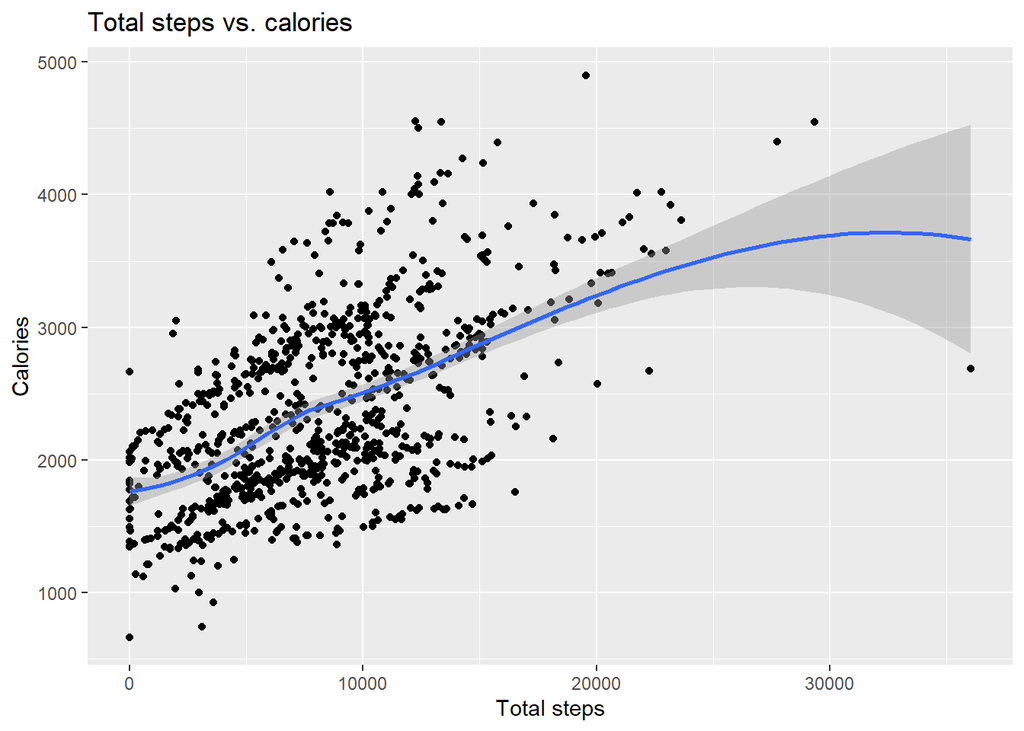

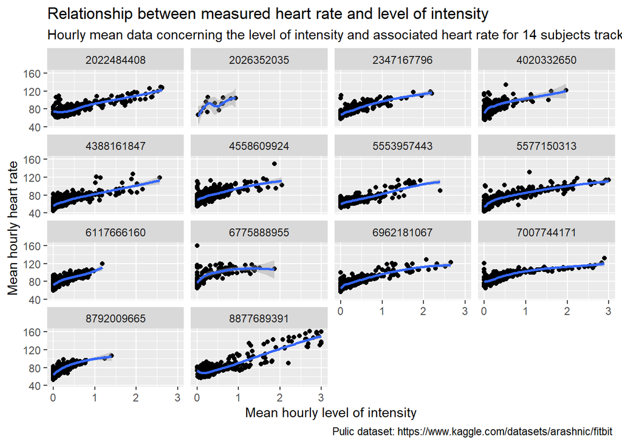

### Sleep

Meanwhile, there is a significant negative correlation between the amount of minues people have stayed sitted or more generally inactive and the amount of time they have spent sleeping.

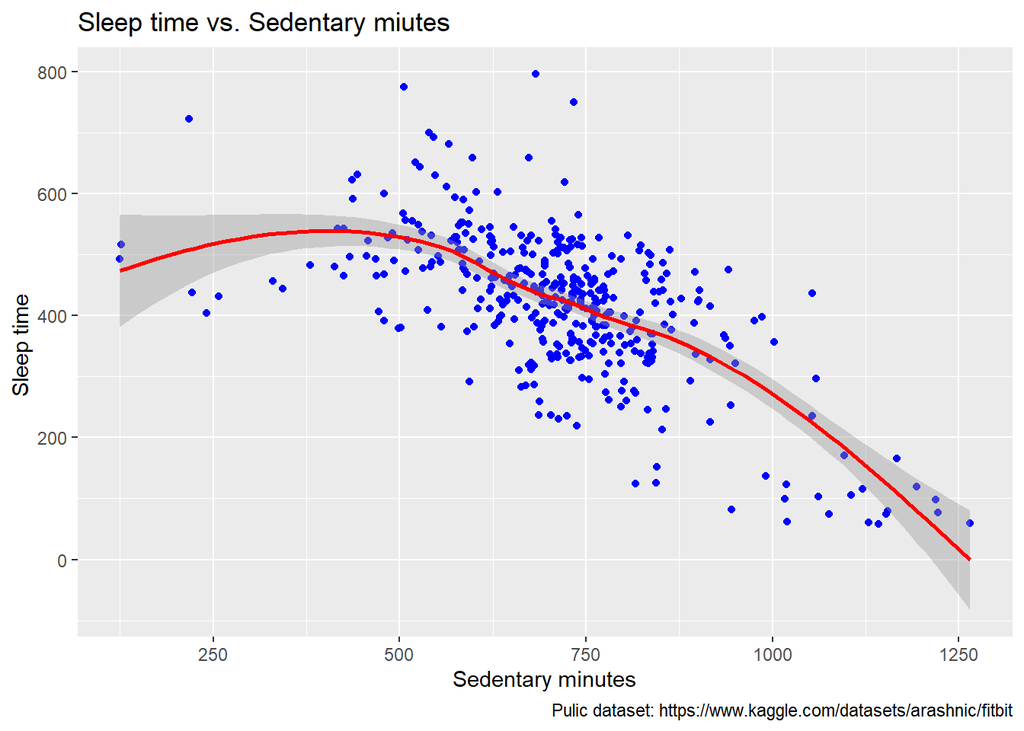

It would be great to dive further into this topic and acquire data that would allow us to measure the quality of sleep and research potential positive correlations between more physical activity and better sleep in terms of quality and/or quantity.

### When are users most active

In this section, we focus on the trends concerning users most active days and hours.

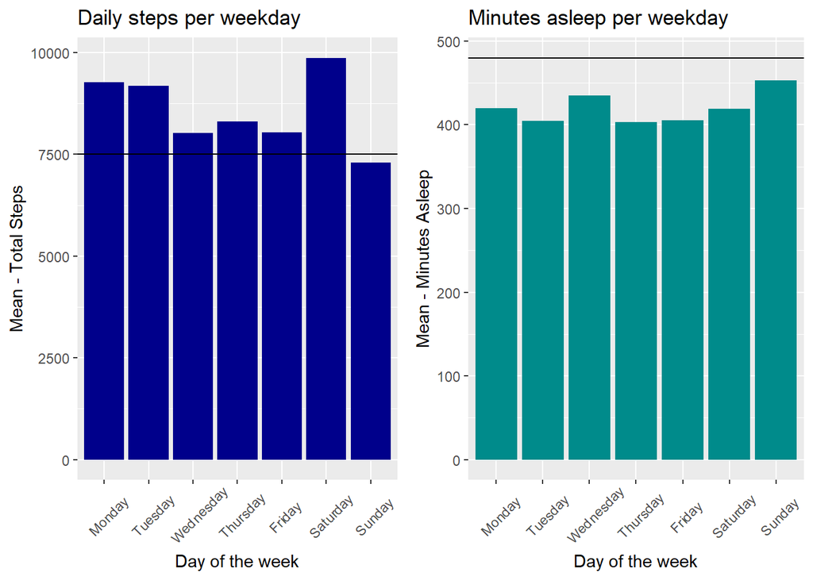

The graphs above ilustrate several interesting trends.

Note that Sunday is the only day where users have not met the quota, albeit artificial, of steps that make for amount to be considered ‘somwhat active’ as per this categorization made by 1000 Steps.

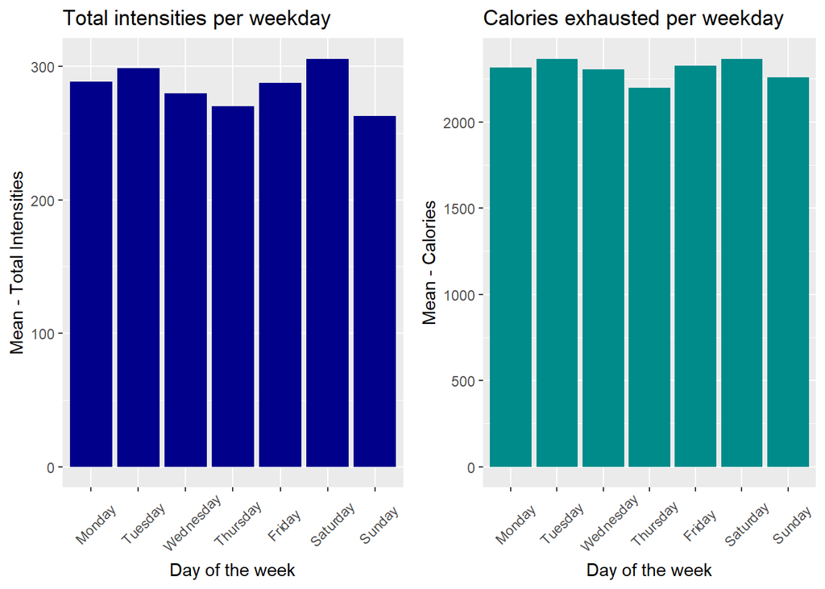

These two graphs confirm the story told by the previous visualization.

Users tend to be most active on Saturday, Tuesday, and Monday and least active on Sunday and during the middle of the work week.

Let’s see in which hours they are the most and least active.

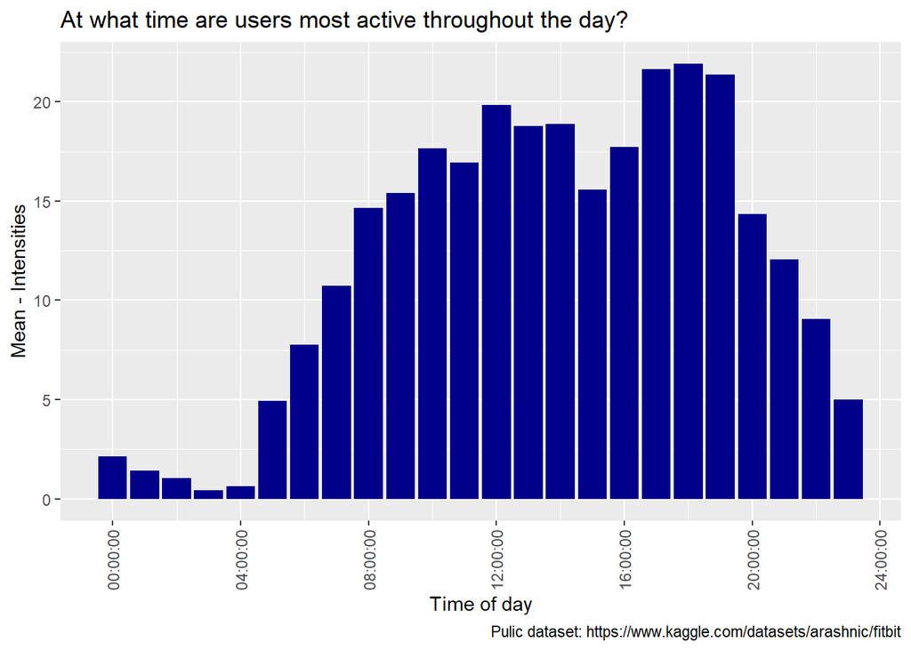

Users are most active between 5 pm and 8 pm, with a noteworthy spike in activitiy midday, around 12 pm. Conversely, activity drops right after 9 and plummets to near 0 between 12 am and 4 am, when people generally tend to sleep.

With this, we have a fairly comprehensive overview of the hours and days users tend to be most and least active. These trends can be leveraged in many ways by Bellabeat, including in its communcation with its users, by giving them a nudge to plan their acitivities around those hours and notify them when those hours and days approach.

Let’s move to the recommendations stage of this presentation in order to dive deeper into this.

## Act - recommendations

In conclusion, we were able to identify some useful trends regarding users’ tracking device usage behavior, as well as some insights related to the impact movement can have on sleep, calories burnt, and the heart rate of users.

These insights and trends can be applied to Bellabeat users in several ways, with the list being non-exhaustive:

Bellabeat can otpimize its communication with users throught the company’s app so as to give more relevant notifications and be more useful for its customers by taking into account when users are most and least active

The app can give more elaborate general advice on the topics of exercise, sleep, and heart rate management to its users and, thus, increase its user-friendliness and overall usefulness for customers

Along the lines of the previous point, Bellabeat can give better personalized advice to its customers based on theri individual goals and preferences *(i.e., prompt a customer who wants to sleep more to increase its active minutes, even if by the slightest, as this will increase their time spent asleep)*

In terms of marketing strategy, Bellabeat can tweak their customer acquisition operations to be more aggressive on Saturdays, Mondays, and Tuesdays, and significantly lowering their efforts on Sundays and in the middle of the week

In addition to those concrete recommendations focused on Bellabeats attitude towards existing and potential customers, I would also recommend the company to:

- expand on efforts to gather data that is more representative, with bigger sample size, and more current, as this will significantly improve the data analysis process
- expand on the data being gathered itself, by including more variables that would allow for deeper analysis

### Credits

As this case study is part of the Google Data Analytics Professional Certificate, there are many individuals who have already had their own take on the project and have shared it publicly. Some of my work has been inspired by some of the projects I have seen both Kaggle and beyond and would like to thank the community for their work. In particular, I want to thank [Anastasiia Chebotina](https://www.kaggle.com/code/chebotinaa/bellabeat-case-study-with-r) and [Macarena Lacasa](https://www.kaggle.com/code/macarenalacasa/capstone-case-study-bellabeat) for their insightful and interesting work.